# Devoir Statistical Learning 3

Louis Henri Franc

1 novembre 2016

```r
library("boot")
knitr::opts_chunk$set(echo = TRUE)
set.seed(123)
```

# Exercice1

$W$ est une matrice de covariance, donc symétrique, positive semi défini.  
On a aussi $\epsilon \sim \mathcal{N}(0,W)$  
Il est possible de faire une décomposition, suivant la formule de Cholesky (matrice hermitienne = matrice symmétrique dans le cas réel)  
Soit $L \in \pmb{\mathbb{R}}^{n,n}$ une matrice triangulaire inférieur.  
$W^{-1} = L^t \cdot L$ car si W est défini positif, $W^{-1}$ l’est aussi. Si l’on ajoute à droite et à gauche de l’équation $L$, on a,  
$L \cdot Y = L \cdot X \cdot \beta + L \dot \epsilon$ **(1)**  
que l’on peut ré écrire  
$Y^* = X^*\cdot \beta + \epsilon^*$  
avec $Y^* = L \cdot Y$, $X^* = L \cdot X$, et $\epsilon^* = L \cdot \epsilon$  
Les propriétés de $\epsilon^*$ sont:

##### **Esperance de $\epsilon^*$**

$E(\epsilon^* | X) = E(L \epsilon^* | X) = L E(\epsilon | X) = 0$

##### **Variance de $\epsilon^*$**

$V(\epsilon^* | X) = E((L \epsilon - 0) (L \epsilon - 0)^t)$  
$V(\epsilon^* | X) = E(L \epsilon \epsilon^t L^t)$  
$V(\epsilon^* | X) = L E(\epsilon \epsilon^t) L^t$  
$V(\epsilon^* | X) = L V(\epsilon) L^t$  
$V(\epsilon^* | X) = L W (L)^t$  
$V(\epsilon^* | X) = L (L^tL)^{-1} L^t$ $V(\epsilon^* | X) = L L^{-1} (L^t)^{-1} L^t$  
$V(\epsilon^* | X) = I_d^n$

On s’est donc ramené à la formule classique de régression linéaire où les erreurs sont indépendantes et identiquement distribuées.  
L’estimateur du maximum de vraisemblance, dans le cas de la régression linéaire, est aussi la solution des moindres carrés.  
On a dans le cas général pour $Y = X \beta + \epsilon$  
$\beta_ {opt} = (X^t X)^{-1}X^t Y$  
Ainsi pour l’équation 1, on a  
$\beta_ {opt} = ((X^*)^t X^*)^{-1}(X^*)^t Y^*$  
$\beta_ {opt} = ((LX)^t LX)^{-1}(LX)^t LY$  
$\beta_ {opt} = ((X^t L^t LX)^{-1}(LX)^t LY$  
$\beta_ {opt} = ((X^t L^t LX)^{-1}X^tL^t LY$  
$\beta_ {opt} = (X^tW^{-1}X)^{-1}X^t W^{-1}Y$

Dans le cas classique de la régression linéaire, l’estimateur $\beta^*$ de beta a une distribution normale asymptotiquement, $\beta^* \sim \mathcal{N}(0,\sigma^2(X^tX)^{-1})$

# Exercice 2

#### Question a (Regression logistique)

##### 1/ Comparaison des modèles avec la méthode LOOCV

Pour comparer les méthodes, j’ai utilisé comme valeur de référence, le MSE et le nombre moyen d’erreurs.

```r
#
# Code implémenté avant d'utiliser la fonction de la librairie boot
#
#

don<-read.csv2("Capteurs.csv")
don$y= as.factor(don$y)
don$y = (don$y == "C")

MSE1 = MSE2 = MSE3 = NBE1 = NBE2 = NBE3 = 0

for (i in 1:length(don$y)) {
  # On prend  un indice pour notre ensemble de test constitué de un élément.
  testIndex = floor(runif(1,1,length(don$y) + 1))

  trainSet = don[-testIndex,]
  testSet = don[testIndex,]

  # Nos trois modèles
  md1 = glm( y ~ x1 + x2 , data = trainSet , family=binomial)
  md2 = glm( y ~ x1 + x2 + I(x1*x2), data = trainSet , family=binomial)
  md3 = glm( y ~ x1 + x2 + I(x1*x2)  + I(x1^2) + I(x2^2), data = trainSet , family=binomial)

  # Les prédictions des trois modèles.
  predict1 = predict(md1, newdata= as.data.frame(testSet[1:2]),type='response')
  predict2 = predict(md2, newdata= as.data.frame(testSet[1:2]),type='response')
  predict3 = predict(md3, newdata= as.data.frame(testSet[1:2]),type='response')

  # Calcul du MSE
  res = ifelse(don$y[testIndex] == TRUE,1,0)
  MSE1 = MSE1 + (predict1 - res) * (predict1 - res)
  MSE2 = MSE2 + (predict2 - res) * (predict2 - res)
  MSE3 = MSE3 + (predict3 - res) * (predict3 - res)

  # Calcul du nombres erreurs
  NBE1 = NBE1 + ifelse(abs(res - predict1) > 0.5,1,0 )
  NBE2 = NBE2 + ifelse(abs(res - predict2) > 0.5,1,0 )
  NBE3 = NBE3 + ifelse(abs(res - predict3) > 0.5,1,0 )
}
# Moyenne des erreurs quadratiques
MSE1 = MSE1 / length(don$y)
MSE2 = MSE2 / length(don$y)
MSE3 = MSE3 / length(don$y)

# taux d'erreur en moyenne
NBE1 = NBE1 / length(don$y)
NBE2 = NBE2 / length(don$y)
NBE3 = NBE3 / length(don$y)

print(paste("MSE modele 1", MSE1))
```

```
## [1] "MSE modele 1 0.0498497260920553"
```

```r
print(paste("MSE modele 2", MSE2))
```

```
## [1] "MSE modele 2 0.0555007823139726"
```

```r
print(paste("MSE modele 3", MSE3))
```

```
## [1] "MSE modele 3 0.0587672126000161"
```

```r
print(paste("Taux d'erreur du modèle 1", NBE1))
```

```
## [1] "Taux d'erreur du modèle 1 0.0583333333333333"
```

```r
print(paste("Taux d'erreur du modèle 2", NBE2))
```

```
## [1] "Taux d'erreur du modèle 2 0.0666666666666667"
```

```r
print(paste("Taux d'erreur du modèle 3", NBE3))
```

```
## [1] "Taux d'erreur du modèle 3 0.0666666666666667"
```

On peut aussi la fonction pré-implenté de la librairie boot.

```r
md1 = glm( y ~ x1 + x2 , data = don , family=binomial)
md2 = glm( y ~ x1 + x2 + I(x1*x2), data = don , family=binomial)
md3 = glm( y ~ x1 + x2 + I(x1*x2)  + I(x1^2) + I(x2^2), data = don , family=binomial)
print(paste("Moyenne des moindres carrés du modele 1", cv.glm(don,md1)$delta[1]))
```

```
## [1] "Moyenne des moindres carrés du modele 1 0.0350971138602514"
```

```r
print(paste("Moyenne des moindres carrés du modele 2", cv.glm(don,md2)$delta[1]))
```

```
## [1] "Moyenne des moindres carrés du modele 2 0.0403047657989856"
```

```r
print(paste("Moyenne des moindres carrés du modele 3", cv.glm(don,md3)$delta[1]))
```

```
## [1] "Moyenne des moindres carrés du modele 3 0.0428787437190857"
```

##### 2/ Comparaison des modèles avec la 10 k-fold Cross Validation

```r
print(paste("Moyenne des moindres carrés du modele 1", cv.glm(don,md1,K = 10)$delta[1]))
```

```
## [1] "Moyenne des moindres carrés du modele 1 0.037918130736454"
```

```r
print(paste("Moyenne des moindres carrés du modele 2", cv.glm(don,md2,K = 10)$delta[1]))
```

```
## [1] "Moyenne des moindres carrés du modele 2 0.0422053069233341"
```

```r
print(paste("Moyenne des moindres carrés du modele 3", cv.glm(don,md3,K = 10)$delta[1]))
```

```
## [1] "Moyenne des moindres carrés du modele 3 0.0446331306849643"
```

##### 3/

Selon les deux méthodes de validation, le modèle qui a le MSE le plus petit est le plus simple $Y = \alpha X1 + \beta X2 + \epsilon$.

#### Question b (Analyse Discriminante)

##### 1/

On calcule tout d’abord la moyenne et la matrice de covariance/variance pour les deux classes.

```r
# Probabilité à priori pour la classe C
priorC = sum(don$y == TRUE) / length(don$y)

# Probabilité à priori pour la classe D
priorD = sum(don$y == FALSE) / length(don$y)

# mu for class C
muC = c(mean(don[which(don$y == TRUE, arr.ind=TRUE),1]), mean(don[which(don$y == TRUE, arr.ind=TRUE),2]))

# mu for class D
muD = c(mean(don[which(don$y == FALSE, arr.ind=TRUE),1]), mean(don[which(don$y == FALSE, arr.ind=TRUE),2]))

# sigma for class C
varC = matrix(nrow = 2 , ncol = 2)

# divide by (n - 1) for sigma_i_i
varC[1,1] = 1/(nrow(don) - 1) * Reduce("+", (don[which(don$y == TRUE, arr.ind=TRUE),1] - rep(muC[1],sum(don$y == TRUE)) ) ^ 2)
varC[2,2] = 1/(nrow(don) - 1) * Reduce("+", (don[which(don$y == TRUE, arr.ind=TRUE),2] - rep(muC[2],sum(don$y == TRUE)) ) ^ 2)
cov_X1_X2 = 0;
for(i in 1:nrow(don)) {
  cov_X1_X2 = cov_X1_X2 + (don$x1[i] - muC[1]) * (don$x2[i] - muC[2])
}
# divide by (n - 2) for sigma_i_j
cov_X1_X2 = cov_X1_X2 / (nrow(don) - 2)
varC[1,2] = cov_X1_X2
varC[2,1] = cov_X1_X2

# sigma for class D
varD = matrix(nrow = 2 , ncol = 2)
varD[1,1] = 1/(nrow(don) - 1) * Reduce("+", (don[which(don$y == FALSE, arr.ind=TRUE),1] - rep(muD[1],sum(don$y == FALSE)) ) ^ 2)
varD[2,2] = 1/(nrow(don) - 1) * Reduce("+", (don[which(don$y == FALSE, arr.ind=TRUE),2] - rep(muD[2],sum(don$y == FALSE)) ) ^ 2)
cov_X1_X2 = 0;
for(i in 1:nrow(don)) {
  cov_X1_X2 = cov_X1_X2 + (don$x1[i] - muD[1]) * (don$x2[i] - muD[2])
}
cov_X1_X2 = cov_X1_X2 / (nrow(don) - 2)
varD[1,2] = cov_X1_X2
varD[2,1] = cov_X1_X2

# Pour la classe C, X suit une loi normale de moyenne
print(muC)
```

```
## [1] 4.107500 4.112167
```

```r
# et de matrice de variance/covariance
print(varC)
```

```
##           [,1]     [,2]
## [1,] 0.3624296 3.628722
## [2,] 3.6287221 0.413817
```

```r
# Pour la classe D, X suit une loi normale de moyenne
print(muD)
```

```
## [1] 1.454333 1.413833
```

```r
# et de matrice de variance/covariance
print(varD)
```

```
##           [,1]      [,2]
## [1,] 0.5202964 3.6287221
## [2,] 3.6287221 0.5494926
```

##### 2,3/

```r
library("MASS")
don<-read.csv2("Capteurs.csv")

# Linear Discriminant Analysis
lda = lda(y ~ x1 + x2,data=don)
# Calculer le taux d'erreur
prev_lda = predict(lda,don)
prev_lda_y = prev_lda$class
taux_err_lda =  mean(prev_lda_y != don$y)
print(paste("Nombre d'erreurs de LDA",taux_err_lda))
```

```
## [1] "Nombre d'erreurs de LDA 0.0416666666666667"
```

```r
print(paste("Equation qui sépare les deux classes est de la forme X1 *",lda$scaling[1]," + X2",lda$scaling[2]))
```

```
## [1] "Equation qui sépare les deux classes est de la forme X1 * -0.763917597895416  + X2 -0.712397407245312"
```

```r
# Quadratic Discriminant Analysis
qda = qda(y ~ x1 + x2,data=don)
# Calculer le taux d'erreur
prev_qda = predict(qda,don)
prev_qda_y = prev_qda$class
taux_err_qda =  mean(prev_qda_y != don$y)
print(paste("Nombre d'erreurs de QDA",taux_err_qda))
```

```
## [1] "Nombre d'erreurs de QDA 0.0416666666666667"
```

#### Question c (KNN)

```r
library("class")
# KNN
# Standardising the data
don_scale = scale(don[,c(1,2)])

# Splitting the data
train = don_scale[0:99,]
test = don_scale[100:120,]
train_X_std = train[,c(1,2)]
test_X_std = test[,c(1,2)]
train_Y = don[0:99,3]
test_Y = don[100:120,3]
knn = knn(train = train_X_std , test = test_X_std , cl = train_Y, k = 5,prob = TRUE)
```

#### Question d (Résume graphique et comparaison)

##### 1/

Pour afficher les courbes séparant les classes suivant les différents modèles, nous allons utiliser la fonction contour.

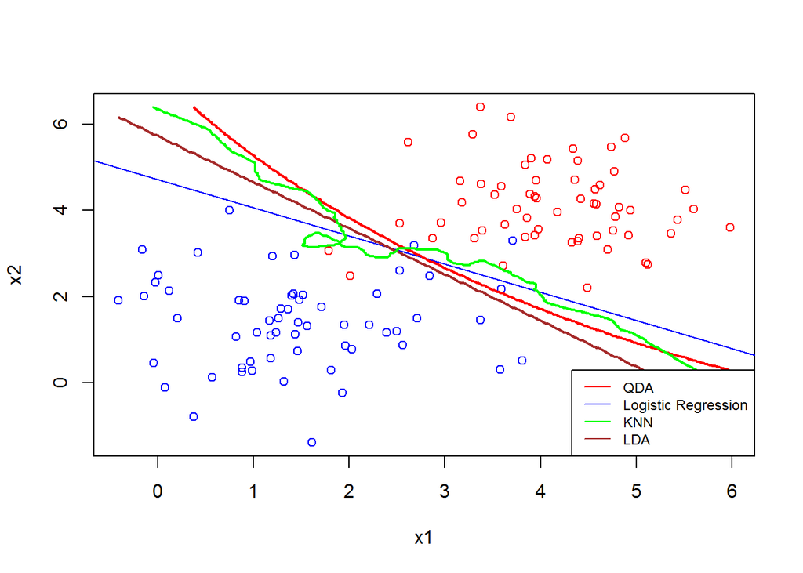

```r
# Logistic Regression boundaries
plot(don[1:2],col = ifelse(don$y == "C","red","blue"),xlab = "x1",ylab = "x2")
slope = coef(md1)[2]/(-coef(md1)[3])
intercept = coef(md1)[1]/(-coef(md1)[3])
abline(intercept , slope , col="blue")

np = 300
# LDA boundaries
bound.x = seq(from = min(don$x1),to = max(don$x1), length.out = np)
bound.y = seq(from = min(don$x2),to =  max(don$x2),length.out =  np)
bound = expand.grid(x1 = bound.x, x2 = bound.y)
prediction = as.numeric(predict(lda, bound)$class)
contour(x = bound.x, y = bound.y, z = matrix(prediction,nrow = np,ncol = np),levels = c(1, 2), add = TRUE, drawlabels = FALSE,col = "brown",lwd = 2)

# QDA boundaries
prediction1 = as.numeric(predict(qda, bound)$class)
contour(x = bound.x, y = bound.y, z = matrix(prediction1,nrow = np,ncol = np),levels = c(1, 2), add = TRUE, drawlabels = FALSE,col = "red",lwd = 2)

# KNN boundaries
# Pour plotter les données, je n'ai pas scaler les données d'entrainements... ce qui rend l'algorithme plus sensible aux variations des features ayant des grandes valeurs
# Cependant ici les valeurs x1, et x2 ont la moyenne, et la même standart deviation, ce qui ne devrait pas poser trop de problèmes.
knn = knn(train = don[,1:2] , test = bound , cl = don[,3], k = 5,prob = TRUE)
# *sd(bound) + mean(bound),
contour(x = bound.x, y = bound.y, z = matrix(as.numeric(knn), nrow = np,ncol = np),levels = c(1, 2), add = TRUE, drawlabels = FALSE,col = "green",lwd = 2)
legend("bottomright", (c("QDA","Logistic Regression","KNN", "LDA")), lty=1, col=c('red', 'blue', 'green',' brown'),  cex=.75)
```

##### 2/

```r
# Determination du taux d'erreur pour les 4 méthodes de classification utilisés précédemment.
# La méthode de validation sera la 10 Fold Cross Validation
nombreFold = length(don$y) / 10
don =  don[sample(nrow(don)),]
folds =  cut(seq(1,nrow(don)) , breaks=nombreFold , labels=FALSE)

NBELDA = 0 # nb erreurs dans LDA
NBEQDA = 0 # nb erreurs dans QDA
NBEKNN = 0 # nb erreurs dans KNN
NBE1 = 0 # nb erreurs dans LR

for (i in 1:length(don$y)) {
  testIndex = floor(runif(1,1,length(don$y) + 1))

  trainSet = don[-testIndex,]
  testSet = don[testIndex,]

  md1 = glm( y ~ x1 + x2 , data = trainSet , family=binomial)
  predict0 = predict(md1, newdata= as.data.frame(testSet[1:2]),type='response')

  predict1 = predict(lda, newdata= as.data.frame(testSet[1:2]),type='response')
  predict2 = predict(qda, newdata= as.data.frame(testSet[1:2]),type='response')
  knn = knn(train=trainSet[,1:2] ,test= testSet[,1:2] , cl= don$y[-testIndex], k = 5,prob = TRUE)

  NBELDA = NBELDA + sum(predict1$class != testSet$y)
  NBEQDA = NBEQDA + sum(predict2$class != testSet$y)
  NBEKNN = NBEKNN + sum(knn != testSet$y)

  res = ifelse(don$y[testIndex] == "D",1,0)
  NBE1 = NBE1 + Reduce("+", ifelse(abs(res - predict0) > 0.5,1,0 ))
}

print(paste("Taux erreur LDA",NBELDA / length(don$y)))
```

```
## [1] "Taux erreur LDA 0.0166666666666667"
```

```r
print(paste("Taux erreur QDA",NBEQDA / length(don$y)))
```

```
## [1] "Taux erreur QDA 0.0166666666666667"
```

```r
print(paste("Taux erreur KNN",NBEKNN / length(don$y)))
```

```
## [1] "Taux erreur KNN 0.0166666666666667"
```

```r
print(paste("Taux erreur de la regression logistique",NBE1 / length(don$y)))
```

```
## [1] "Taux erreur de la regression logistique 0.0416666666666667"
```

# Exercice 3

#### Question a

```r
head(iris)
```

```
##   Sepal.Length Sepal.Width Petal.Length Petal.Width Species
## 1          5.1         3.5          1.4         0.2  setosa
## 2          4.9         3.0          1.4         0.2  setosa
## 3          4.7         3.2          1.3         0.2  setosa
## 4          4.6         3.1          1.5         0.2  setosa
## 5          5.0         3.6          1.4         0.2  setosa
## 6          5.4         3.9          1.7         0.4  setosa
```

On souuhaite estimer le paramètre défini par $l = \mathbb{E}(min(X_1 + X_2, X_1 + X_3 + X_4, X_2 + X_3))$. Pour tout $i = 1,...,150$, $xi = (x_{i1}, x_{i2}, x_{i3}, x_{i4})$ est une observation d’un vecteur aléatoire $X = (X_1, x_2, X_3, X_4)^t$

Un estimateur de $l = \mathbb{E}(min{X_1 + X_2, X_1 + X_3 + X_4, X_2 + X_3})$ peut être par exemple $\hat{l} = min(\mathbb{E}(X_1 + X_2), \mathbb{E}(X_1 + X_3 + X_4), \mathbb{E}(X_2 + X_3))$.

On peut approximer l’espérance par les données que l’on a, on a donc $\hat{l} = min(\sum\limits_{i=1}^{150} \frac{x_{i1} + x_{i2}}{150},\sum\limits_{i=1}^{150} \frac{x_{i1} + x_{i3} + x_{i4}}{150}, \sum\limits_{i=1}^{150} \frac{x_{i2} + x_{i3}}{150})$

#### Question b

Pour estimer le paramètre $\hat{l}$, on va utiliser la méthode de bootstrap.

```r
model1.fn = function(data,index) {
  mean(data[index,1]) + mean(data[index,2])
}

model2.fn = function(data,index) {
  mean(data[index,1]) + mean(data[index,3]) + mean(data[index,4])
}

model3.fn = function(data,index) {
  mean(data[index,2]) + mean(data[index,3])
}

boot(iris, model1.fn, R = 1500)$t0
```

```
## [1] 8.900667
```

```r
boot(iris, model2.fn, R = 1500)$t0
```

```
## [1] 10.80067
```

```r
boot(iris, model3.fn, R = 1500)$t0
```

```
## [1] 6.815333
```

Le modèle 3 est le minimum, nous allons le garder pour trouver un encadrement de notre paramètre $\hat{l}$.

```r
d = boot(iris, model3.fn, R = 1500)
# L'estimation du biais et de l'ecart type est déja donné dans les résultats
# biais
mean(d$t) - d$t0
```

```
## [1] -0.005763556
```

```r
# ecart type
sd(d$t)
```

```
## [1] 0.1323155
```

```r
# L'intervalle de confiance de l_hat est [ min_l, max_l ]
min_l = d$t0 - 2*sd(d$t)

# et
max_l = d$t0 + 2*sd(d$t)
print(paste("[ ",min_l," , ",max_l," ]"))
```

```
## [1] "[  6.55070237254762  ,  7.07996429411905  ]"
```